# M07-SVM

Raman Kannan

9/28/2020

## Preliminaries

#Load input data heart.csv and ecoli.csv

```r
unixpath<-"/home/data/ML.Data/heart.csv"
unixecolipath<-"/home/data/ML.Data/ecoli.csv"
path<-"c://Users/rk215/Data/heart.csv"
ecolipath<-"c://Users/rk215/Data/ecoli.csv"
heart<-read.csv(path,header=TRUE,sep=',',stringsAsFactors=FALSE)
ecoli<-read.csv(ecolipath,head=T,sep=',',stringsAsFactors=F)
```

## Review the data, quick and easy EDA

View a few records (head/tail), dimension, number of rows and records and the variable names. Everything is an object and mostly a list. We can index into a list to access the elements in the list. R index runs from 1 to the length.

```r
head(heart)
```

```
##   age sex cp trestbps chol fbs restecg thalach exang oldpeak slope ca thal
## 1  63   1  3      145  233   1       0     150     0     2.3     0  0    1
## 2  37   1  2      130  250   0       1     187     0     3.5     0  0    2
## 3  41   0  1      130  204   0       0     172     0     1.4     2  0    2
## 4  56   1  1      120  236   0       1     178     0     0.8     2  0    2
## 5  57   0  0      120  354   0       1     163     1     0.6     2  0    2
## 6  57   1  0      140  192   0       1     148     0     0.4     1  0    1
##   target
## 1      1
## 2      1
## 3      1
## 4      1
## 5      1
## 6      1
```

### unix head and tail commands

R commands *head* and *tail* are like the Unix head and tail shell commands These commands output a few records from the beginning or at the end of the file.

```r
tail(heart)
```

```
##     age sex cp trestbps chol fbs restecg thalach exang oldpeak slope ca thal
## 298  59   1  0      164  176   1       0      90     0     1.0     1  2    1
## 299  57   0  0      140  241   0       1     123     1     0.2     1  0    3
## 300  45   1  3      110  264   0       1     132     0     1.2     1  0    3
## 301  68   1  0      144  193   1       1     141     0     3.4     1  2    3
## 302  57   1  0      130  131   0       1     115     1     1.2     1  1    3
## 303  57   0  1      130  236   0       0     174     0     0.0     1  1    2
##     target
## 298      0
## 299      0
## 300      0
## 301      0
## 302      0
## 303      0
```

let us change the name of the first column

```r
names(heart)[[1]]<-'age'
```

Always trust but verify that our indexing worked…

```r
names(heart)
```

```
##  [1] "age"      "sex"      "cp"       "trestbps" "chol"     "fbs"
##  [7] "restecg"  "thalach"  "exang"    "oldpeak"  "slope"    "ca"
## [13] "thal"     "target"
```

We have already performed EDA when we ran glm.

```r
library(plotly)
library(e1071)
library(caret)
library(pROC)
```

## Let us run

Let us run SVM from e1071 package and try to understand each variable and how important they are in determining the target variable.

we will **NOT** split the data as this is a trial run and this run is to develop a rough draft script for any classification exercise.

```r
heart$target<-factor(heart$target)
svm_model<-svm(target~.,data=heart, probability=TRUE)
svm_model
```

```
##
## Call:
## svm(formula = target ~ ., data = heart, probability = TRUE)
##
##
## Parameters:
##    SVM-Type:  C-classification
##  SVM-Kernel:  radial
##        cost:  1
##
## Number of Support Vectors:  174
```

```r
svm_predict<-predict(svm_model,heart[,-c(14)],probability=TRUE)
probs<-attr(svm_predict,"prob")[,"1"]
predclass<-ifelse(probs>0.5,1,0)
table(heart$target==predclass)
```

```
##
## FALSE  TRUE
##    24   279
```

```r
(cfmx<-caret::confusionMatrix(table(heart$target,predclass)))
```

```
## Confusion Matrix and Statistics
##
##    predclass
##       0   1
##   0 125  13
##   1  11 154
##
##                Accuracy : 0.9208
##                  95% CI : (0.8844, 0.9486)
##     No Information Rate : 0.5512
##     P-Value [Acc > NIR] : <2e-16
##
##                   Kappa : 0.8401
##
##  Mcnemar's Test P-Value : 0.8383
##
##             Sensitivity : 0.9191
##             Specificity : 0.9222
##          Pos Pred Value : 0.9058
##          Neg Pred Value : 0.9333
##              Prevalence : 0.4488
##          Detection Rate : 0.4125
##    Detection Prevalence : 0.4554
##       Balanced Accuracy : 0.9206
##
##        'Positive' Class : 0
##
```

### Our model can learn ….

```r
set.seed(43)
tstidx<-sample(1:nrow(heart),0.30*nrow(heart),replace=F)
trdata<-heart[-tstidx,]
tsdata<-heart[tstidx,]

#svm(target~.,data=heart, probability=TRUE)

svm_train_model<-svm(target~.,data=trdata,probability=TRUE)
svm_train_predict<-predict(svm_train_model,trdata[,-c(14)],probability=TRUE)
train_probs<-attr(svm_train_predict,"prob")[,"1"]
train_predclass<-ifelse(train_probs>0.5,1,0)
tr_tbl<-table(trdata$target,train_predclass)
(tr_cfmx<-caret::confusionMatrix(tr_tbl))
```

```
## Confusion Matrix and Statistics
##
##    train_predclass
##       0   1
##   0  84  10
##   1   7 112
##
##                Accuracy : 0.9202
##                  95% CI : (0.8753, 0.9528)
##     No Information Rate : 0.5728
##     P-Value [Acc > NIR] : <2e-16
##
##                   Kappa : 0.8376
##
##  Mcnemar's Test P-Value : 0.6276
##
##             Sensitivity : 0.9231
##             Specificity : 0.9180
##          Pos Pred Value : 0.8936
##          Neg Pred Value : 0.9412
##              Prevalence : 0.4272
##          Detection Rate : 0.3944
##    Detection Prevalence : 0.4413
##       Balanced Accuracy : 0.9206
##
##        'Positive' Class : 0
##
```

```r
cdf<-data.frame(all=cfmx$byClass,tr=tr_cfmx$byClass)
cdf
```

```
##                            all        tr
## Sensitivity          0.9191176 0.9230769
## Specificity          0.9221557 0.9180328
## Pos Pred Value       0.9057971 0.8936170
## Neg Pred Value       0.9333333 0.9411765
## Precision            0.9057971 0.8936170
## Recall               0.9191176 0.9230769
## F1                   0.9124088 0.9081081
## Prevalence           0.4488449 0.4272300
## Detection Rate       0.4125413 0.3943662
## Detection Prevalence 0.4554455 0.4413146
## Balanced Accuracy    0.9206367 0.9205549
```

The performance measures are very similar therefore we can conclude the data partition has no impact on the distribution or the model performance and the model is stable. Now we can evaluate the performance on the test set.

```r
svm_tst_predict<-predict(svm_train_model,tsdata[,-c(14)],probability=TRUE)
tst_probs<-attr(svm_tst_predict,"prob")[,"1"]
tst_predclass<-ifelse(tst_probs>0.5,1,0)
tst_tbl<-table(tsdata$target,tst_predclass)
(tst_cfmx<-caret::confusionMatrix(tst_tbl))
```

```
## Confusion Matrix and Statistics
##
##    tst_predclass
##      0  1
##   0 38  6
##   1  5 41
##
##                Accuracy : 0.8778
##                  95% CI : (0.7918, 0.9374)
##     No Information Rate : 0.5222
##     P-Value [Acc > NIR] : 7.423e-13
##
##                   Kappa : 0.7553
##
##  Mcnemar's Test P-Value : 1
##
##             Sensitivity : 0.8837
##             Specificity : 0.8723
##          Pos Pred Value : 0.8636
##          Neg Pred Value : 0.8913
##              Prevalence : 0.4778
##          Detection Rate : 0.4222
##    Detection Prevalence : 0.4889
##       Balanced Accuracy : 0.8780
##
##        'Positive' Class : 0
##
```

```r
cdf<-cbind(cdf,ts=tst_cfmx$byClass)
cdf
```

```
##                            all        tr        ts
## Sensitivity          0.9191176 0.9230769 0.8837209
## Specificity          0.9221557 0.9180328 0.8723404
## Pos Pred Value       0.9057971 0.8936170 0.8636364
## Neg Pred Value       0.9333333 0.9411765 0.8913043
## Precision            0.9057971 0.8936170 0.8636364
## Recall               0.9191176 0.9230769 0.8837209
## F1                   0.9124088 0.9081081 0.8735632
## Prevalence           0.4488449 0.4272300 0.4777778
## Detection Rate       0.4125413 0.3943662 0.4222222
## Detection Prevalence 0.4554455 0.4413146 0.4888889
## Balanced Accuracy    0.9206367 0.9205549 0.8780307
```

# Let us now run the SVM on the attributed we identified with VIF

```r
Y<-heart[[14]]
vif_col<-c(2,3,6,7,9,11,12,13,14)
vif_heart<-heart[,vif_col]
vif_trdata<-trdata[,vif_col]
vif_tsdata<-tsdata[,vif_col]
head(vif_heart)
```

```
##   sex cp fbs restecg exang slope ca thal target
## 1   1  3   1       0     0     0  0    1      1
## 2   1  2   0       1     0     0  0    2      1
## 3   0  1   0       0     0     2  0    2      1
## 4   1  1   0       1     0     2  0    2      1
## 5   0  0   0       1     1     2  0    2      1
## 6   1  0   0       1     0     1  0    1      1
```

```r
head(Y)
```

```
## [1] 1 1 1 1 1 1
## Levels: 0 1
```

```r
svm_vif_tr_model<-svm(target~.,data=vif_trdata,probability=TRUE)
svm_vif_tr_predict<-predict(svm_vif_tr_model,vif_trdata[,-c(14)],probability=TRUE)
vif_train_probs<-attr(svm_vif_tr_predict,"prob")[,"1"]
vif_train_predclass<-ifelse(vif_train_probs>0.5,1,0)
vif_tr_tbl<-table(vif_trdata$target,vif_train_predclass)
(vif_tr_cfmx<-caret::confusionMatrix(vif_tr_tbl))
```

```
## Confusion Matrix and Statistics
##
##    vif_train_predclass
##       0   1
##   0  81  13
##   1   6 113
##
##                Accuracy : 0.9108
##                  95% CI : (0.8642, 0.9454)
##     No Information Rate : 0.5915
##     P-Value [Acc > NIR] : <2e-16
##
##                   Kappa : 0.8177
##
##  Mcnemar's Test P-Value : 0.1687
##
##             Sensitivity : 0.9310
##             Specificity : 0.8968
##          Pos Pred Value : 0.8617
##          Neg Pred Value : 0.9496
##              Prevalence : 0.4085
##          Detection Rate : 0.3803
##    Detection Prevalence : 0.4413
##       Balanced Accuracy : 0.9139
##
##        'Positive' Class : 0
##
```

```r
(cdf<-cbind(cdf,vif_tr=vif_tr_cfmx$byClass)) # this represents our model's ability to learn -- training error
```

```
##                            all        tr        ts    vif_tr
## Sensitivity          0.9191176 0.9230769 0.8837209 0.9310345
## Specificity          0.9221557 0.9180328 0.8723404 0.8968254
## Pos Pred Value       0.9057971 0.8936170 0.8636364 0.8617021
## Neg Pred Value       0.9333333 0.9411765 0.8913043 0.9495798
## Precision            0.9057971 0.8936170 0.8636364 0.8617021
## Recall               0.9191176 0.9230769 0.8837209 0.9310345
## F1                   0.9124088 0.9081081 0.8735632 0.8950276
## Prevalence           0.4488449 0.4272300 0.4777778 0.4084507
## Detection Rate       0.4125413 0.3943662 0.4222222 0.3802817
## Detection Prevalence 0.4554455 0.4413146 0.4888889 0.4413146
## Balanced Accuracy    0.9206367 0.9205549 0.8780307 0.9139299
```

```r
# is interpreted as underfitting when < 0.75 I use 0.85
# remedy is to consider more complex model
```

```r
svm_vif_tst_predict<-predict(svm_vif_tr_model,vif_tsdata[,-c(9)], probability=TRUE)
svm_vif_tst_predict_probs=attr(svm_vif_tst_predict, "prob")[,"1"]
svm_roc_obj<-roc(vif_tsdata[,c(9)],svm_vif_tst_predict_probs)
svm_auc<-auc(svm_roc_obj)
```

Now let us plot ROC Curve

[figure not shown]

```r
plot.new()
plot.window(xlim=c(1,0), ylim=c(0,1), xaxs='i', yaxs='i')
axis(1, las=1)
axis(2, las=1)
abline(1,-1, col="black", lwd=0.5)
box()
title(main="ROC", xlab="Specificity", ylab="Sensitivity")
lines(svm_roc_obj, col="black", las=2)
text(x=0.2,y=0.2,paste("SVM_AUC=",round(svm_auc,6),sep=''))
```

SVM by far has some attractive properties. Adding new observations to the left or right of the computed support vectors does not change the support vectors and our inferences are stable as new data arrives. SVM needs to carry the vectors nothing more – not the dataset as we did in the case of kNN. SVMs are most explainable determined by directly by the data.

The decision boundary for a SVM is linear (recall it is straight line) SVMs are most known for its customizability using kernel trick. Here let us look at an example from ESL book which demonstrates the power of SVM when the boundary is not linear. Download this data, https://web.stanford.edu/~hastie/ElemStatLearn/datasets/ESL.mixture.rda from the ESL book site.

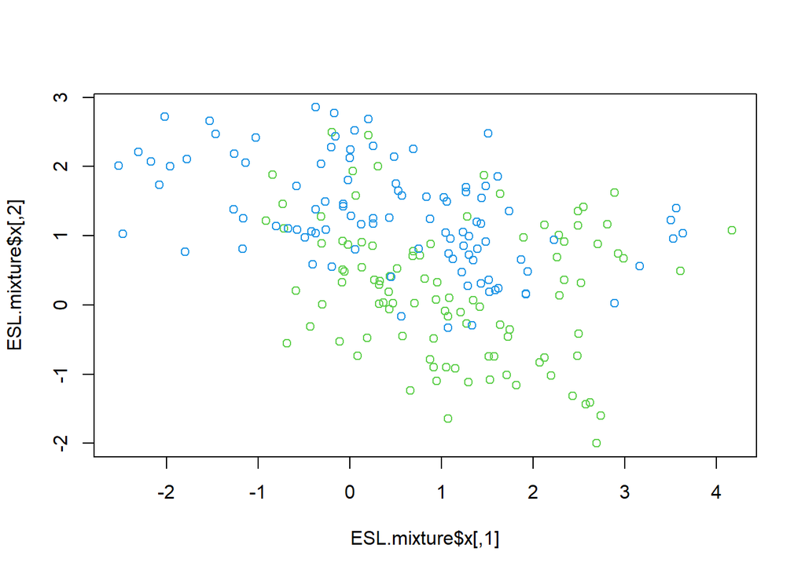

```r
load(url("https://web.stanford.edu/~hastie/ElemStatLearn/datasets/ESL.mixture.rda"))
plot(ESL.mixture$x,col=ESL.mixture$y+3)
```

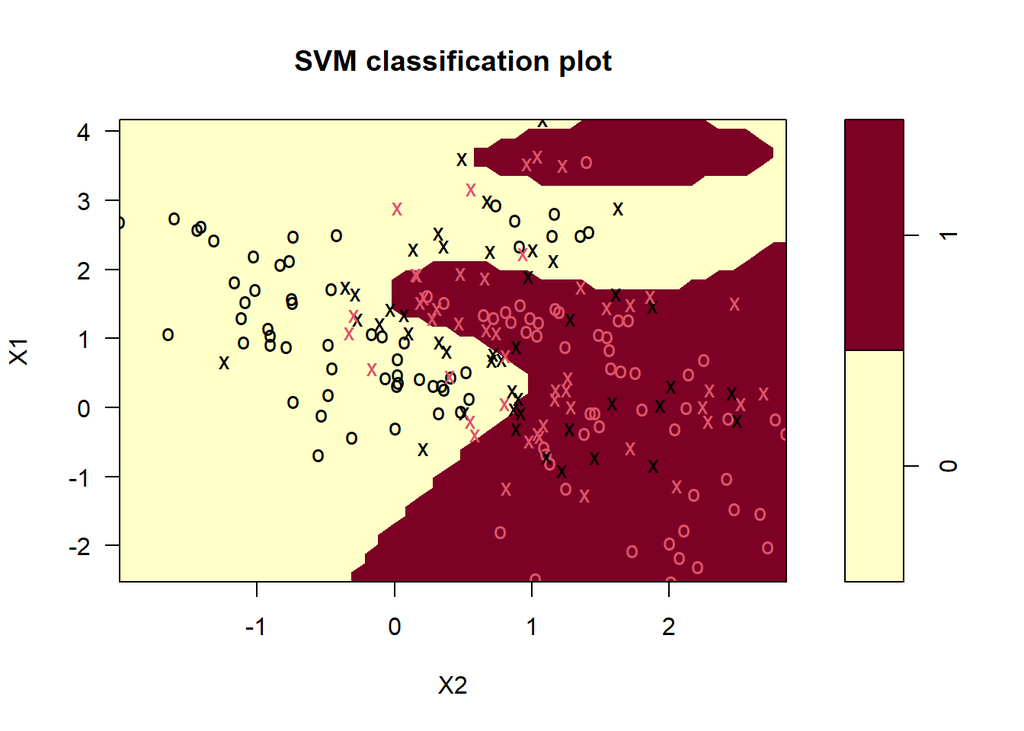

```r
data_svm<-data.frame(y=factor(ESL.mixture$y),ESL.mixture$x)

 data.svm<-svm(factor(y)~.,data=data_svm,scale=FALSE,kernel="radial",cost=15)
 plot(data.svm,data_svm)
```

Clearly this is not a linear boundary but SVM does this even though the data is not separable. The performance of this model may be computed just as we have been doing and that is left as an exercise, not for credit though.

For Software Engineers, kernel technique, just passing in method as a parameter, is not new.